# Introduction to scRNA-seq - Part III: Clustering and annotating

Maria Vlachonikolou

30/05/2023

# Clustering

*Questions to be answered in the protocol:*

** What are clusters?**

Simply put, clusters are cells which are grouped together based on similar gene expression patterns. Shared gene expression patterns suggest that cells belong to the same cell type/ developmental state.

** Why are cells grouped to clusters? What are the benefits / disadvantages to do so?**

Clustering cells using scRNAseq data has has revolutionized the ability to characterize cell types, as we now have access to the transcriptional information that goes beyond the phenotypic characteristics, which are merely a reflection of the underlying transcriptional profiles.

One of the goals of clustering the cells is reducing the effect of dropouts. In single-cell RNA-seq not all transcripts are captured and sequenced, but only a fraction of them. Because of that, it is imposible to cluster based only on the expression of already known markers. By considering the expression patterns of multiple genes across cells, clustering algorithms can identify clusters of cells that share similar gene expression profiles. Within each cluster, the presence of dropouts in individual genes may be compensated by the expression of other genes within the same cluster.

Once the cells are clustered, it is possible to characterize the clusters based on the expression of marker genes, study their characteristics and find differentially expressed genes across them that will provide insights into the underlying biology of the studied system.

Defining clusters also presents several challenges.

In previous steps we set the number of variable genes to the top 2000 and chose 30 PCs. These choices removed some variability from the data in exchange for less noise and computational time. These numbers should not be set arbitrarily, as the ideal values for robust cell type identification can vary depending on the level of initial heterogeneity.

Finding the optimal number of clusters can be challenging. If the number of clusters is too low, it may result in merging distinct cell types into a single cluster. Conversely, if the number of clusters is too high, it can result in over-splitting and creating meaningless subpopulations.

The fact that the analysis concerns biological systems should always be kept in mind. Different cell types have emerged through evolutionary and developmental processes which not always set clear boundaries between those types. So, sometimes cells can be part of continuous spectrum of states. In many biological systems, cell types do not have well-defined boundaries. Setting the boundaries ourselves to serve the aims of the study can prove challenging. Non-discrete methods, such as pseudotemporal ordering, can help capture and visualize the continuous progression of cell states.

** What does the clustering resolution parameter do?**

The `FindClusters()` function in the analysis pipeline has a parameter called “resolution” that determines the level of detail in the resulting clusters. Higher values of the resolution parameter lead to more and smaller clusters, while lower values create less and larger clusters.

** Why do we use different resolutions?**

The resolution parameter controls the level of detail in the resulting clusters. When trying to identify broad cell types, low resolution is preferred. On the other hand, subtle differences and smaller subpopulations can be revealed using high resolution. However, careful consideration is advised when opting for a high resolution parameter setting, as it can lead to over-clustering and to artificial distinctions. Once again, the optimum value for this parameter depends on the data set’s characteristics (size, complexity, origin), as well as, the aims of the study.

** How can you find genes that are specific to a cluster?**

The FindAllMarkers() function in Seurat finds differentially expressed genes (markers) for each cluster compared to all other cells. It is also possible to find the markers of a specific cluster or within a group of clusters with the FindMarkers() function. These functions can use a variety of statistical tests such as Wilcoxon Rank Sum test (default), Student’s t-test, Likelihood-ratio test etc.

Wilcoxon Rank Sum test is a non-parametric method (does not make assumptions about the underlying probability distribution of the population). The null hypothesis is that the two populations have equal medians. The observations of the combined samples are ranked (e.g. from lowest to highest). The sums of the ranks of observations for each population are calculated, adjusted to consider the difference in group sizes and then compared to each other. Under null-hypothesis the two sums are expected to be similar. To determine if the difference in ranks is statistically significant, the test calculates a p-value.

The min.pct argument requires a feature to be detected at a minimum percentage in either of the two populations in order to test it. This skips infrequently expressed genes and speeds up the process.

** Why do we have to do p-value adjustment/multiple hypothesis testing when searching for cluster specific genes?**

p-value adjustment aims to control the Type I error rate, meaning rejecting the null hypothesis in cases where it is true which leads to false positive results. In the search for differentially expressed genes across clusters thousands of genes are being tested. With multiple tests, the chances of observing at least one extreme result by chance alone increase, leading to an inflation of false positives. This phenomenon is known as the multiple hypothesis testing problem.

If the significance level (α) is set to the usual 0.05 value for example, it means that for every gene considered differentially expressed to a significant level there is a chance up to 5% to be a false positive. This chance, although small on its own, when multiplied by a large number of genes can lead to a considerable number of false positives. The FindAllMarkers() and FindMarkers() functions use the Bonferroni correction method. In this method, the p-value is multiplied by the number of hypothesis tests and then compared to the study-wide significance level.

## Load packages

```r
library(Seurat)
library(dplyr)
```

## Clean environment

```r
rm(list = ls())
gc()
```

```
##           used  (Mb) gc trigger  (Mb) limit (Mb) max used  (Mb)
## Ncells 3048207 162.8    5003317 267.3         NA  5003317 267.3
## Vcells 5239626  40.0   10146329  77.5      16384  7037015  53.7
```

## Load data

```r
ple5 <- readRDS("srt_02_ple5v2.rds")
```

```r
ple5
```

```
## An object of class Seurat
## 13103 features across 2334 samples within 1 assay
## Active assay: RNA (13103 features, 2000 variable features)
##  3 dimensional reductions calculated: pca, tsne, umap
```

The dimensional reduction information from PCA, t-SNE and UMAP analysis is stored in the Seurat object.

## Finding clusterings of different resolutions

First, a graph is constructed based on the distances between cells in the principal component analysis (PCA) space. The k closest cells are connected as neighbors in the graph.

The first step is to construct a k-nearest neighbor graph based on the euclidean distance in PCA space. The k closest cells are connected as neighbors in the graph. The edge weights between any two cells are refined based on the shared overlap in their local neighborhoods (Jaccard similarity). This step is performed using the FindNeighbors() function, and takes as input the previously defined dimensionality of the dataset.

```r
ple5 <- FindNeighbors(ple5, reduction="pca", dims=1:30, k.param=20)
```

Next, clusters of cells are identified using the Louvain algorithm. The objective is to merge communities based on maximizing the number of shared neighbors within a community and minimizing the number of shared neighbors between communities. This process aims to optimize a measure called modularity, which quantifies the quality of the community structure in the graph. Here the fuction is run for different resolutions.

```r
ple5 <- FindClusters(ple5, resolution = c(0.1, 0.5, 0.7, 1, 1.5, 2, 3))
```

```
## Modularity Optimizer version 1.3.0 by Ludo Waltman and Nees Jan van Eck
##
## Number of nodes: 2334
## Number of edges: 63512
##
## Running Louvain algorithm...
## Maximum modularity in 10 random starts: 0.9716
## Number of communities: 11
## Elapsed time: 0 seconds
## Modularity Optimizer version 1.3.0 by Ludo Waltman and Nees Jan van Eck
##
## Number of nodes: 2334
## Number of edges: 63512
##
## Running Louvain algorithm...
## Maximum modularity in 10 random starts: 0.9320
## Number of communities: 19
## Elapsed time: 0 seconds
## Modularity Optimizer version 1.3.0 by Ludo Waltman and Nees Jan van Eck
##
## Number of nodes: 2334
## Number of edges: 63512
##
## Running Louvain algorithm...
## Maximum modularity in 10 random starts: 0.9183
## Number of communities: 20
## Elapsed time: 0 seconds
## Modularity Optimizer version 1.3.0 by Ludo Waltman and Nees Jan van Eck
##
## Number of nodes: 2334
## Number of edges: 63512
##
## Running Louvain algorithm...
## Maximum modularity in 10 random starts: 0.8997
## Number of communities: 22
## Elapsed time: 0 seconds
## Modularity Optimizer version 1.3.0 by Ludo Waltman and Nees Jan van Eck
##
## Number of nodes: 2334
## Number of edges: 63512
```

[output cut: 8 more lines]

```
## Number of edges: 63512
##
## Running Louvain algorithm...
## Maximum modularity in 10 random starts: 0.8519
## Number of communities: 29
## Elapsed time: 0 seconds
## Modularity Optimizer version 1.3.0 by Ludo Waltman and Nees Jan van Eck
##
## Number of nodes: 2334
## Number of edges: 63512
##
## Running Louvain algorithm...
## Maximum modularity in 10 random starts: 0.8100
## Number of communities: 32
## Elapsed time: 0 seconds
```

```r
head(ple5[[]])
```

```
##                   orig.ident nCount_RNA nFeature_RNA percent_mito
## TCAGCCTGTTTACGTG Pleurodeles      29999         5725    0.6266876
## CAACAGTGTTAGAAGT Pleurodeles      29764         5733    1.8411504
## CATGCGGGTCCTACAA Pleurodeles      29703         5834    1.1210989
## AAACCCATCCTTCTTC Pleurodeles      29647         5733    0.4081357
## CCTCACAAGATGGGCT Pleurodeles      29645         5801    1.0895598
## GAAGGGTAGATAGCTA Pleurodeles      29640         5734    0.3609987
##                  RNA_snn_res.0.1 RNA_snn_res.0.5 RNA_snn_res.0.7 RNA_snn_res.1
## TCAGCCTGTTTACGTG               5              10              10            11
## CAACAGTGTTAGAAGT               3               8               8             7
## CATGCGGGTCCTACAA               3               2               1             0
## AAACCCATCCTTCTTC               3               2               1             0
## CCTCACAAGATGGGCT               0               6               5             3
## GAAGGGTAGATAGCTA               3               8               8             7
##                  RNA_snn_res.1.5 RNA_snn_res.2 RNA_snn_res.3 seurat_clusters
## TCAGCCTGTTTACGTG              10             9             7               7
## CAACAGTGTTAGAAGT               4             2            17              17
## CATGCGGGTCCTACAA               6            18            19              19
## AAACCCATCCTTCTTC              13            11            10              10
## CCTCACAAGATGGGCT               1            21            20              20
## GAAGGGTAGATAGCTA               4             2            11              11
```

The cell idents have been updated with new cluster information. Each cell now, for a set resolution, belongs to a certain cluster. (‘seurat_clusters’ stores the latest clustering results and will be overwritten everytime FindClusters is run.)

Visualise the clusters

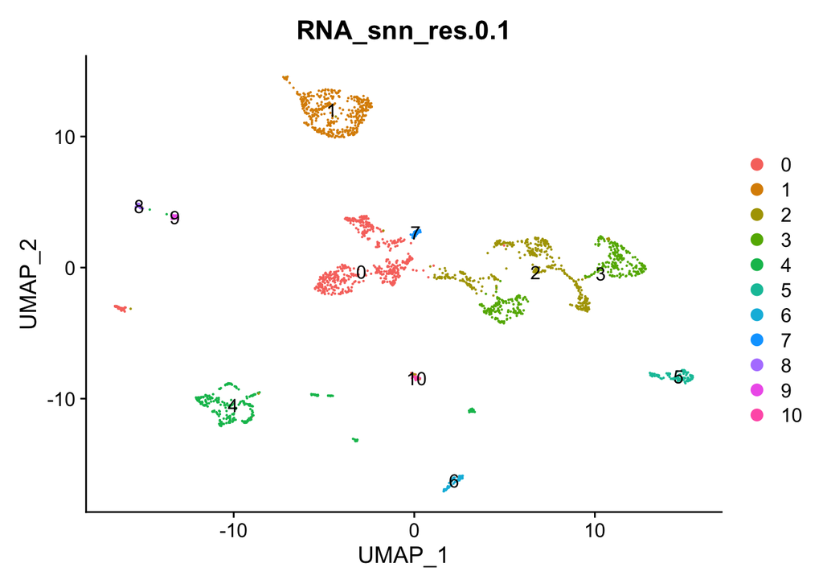

```r
ple5 <- SetIdent(ple5, value="orig.ident")
DimPlot(ple5, group.by="RNA_snn_res.0.1", label=TRUE, pt.size = 0.05)
```

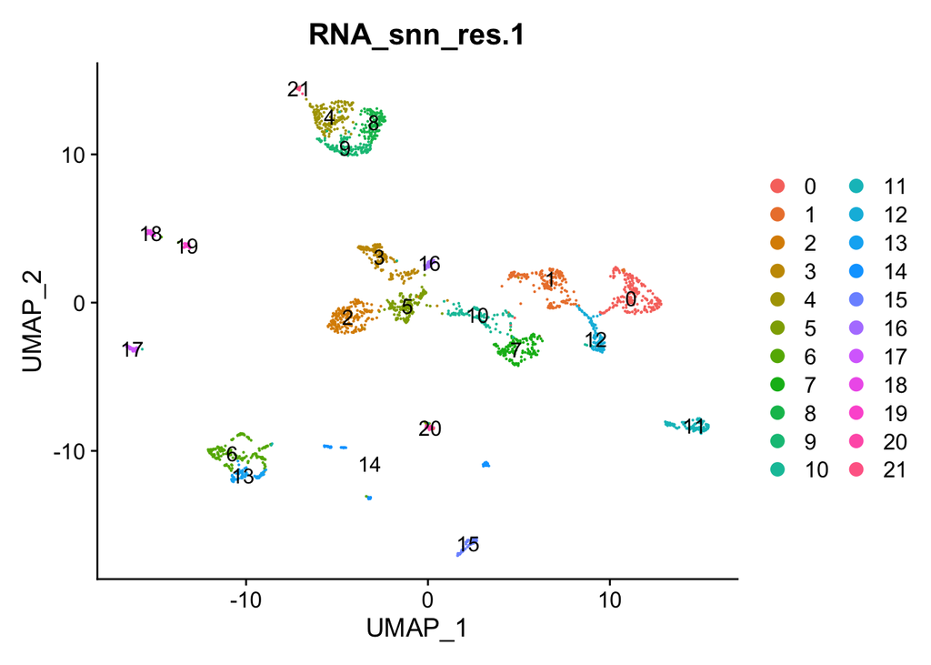

```r
DimPlot(ple5, group.by="RNA_snn_res.1", label=TRUE, pt.size = 0.05)
```

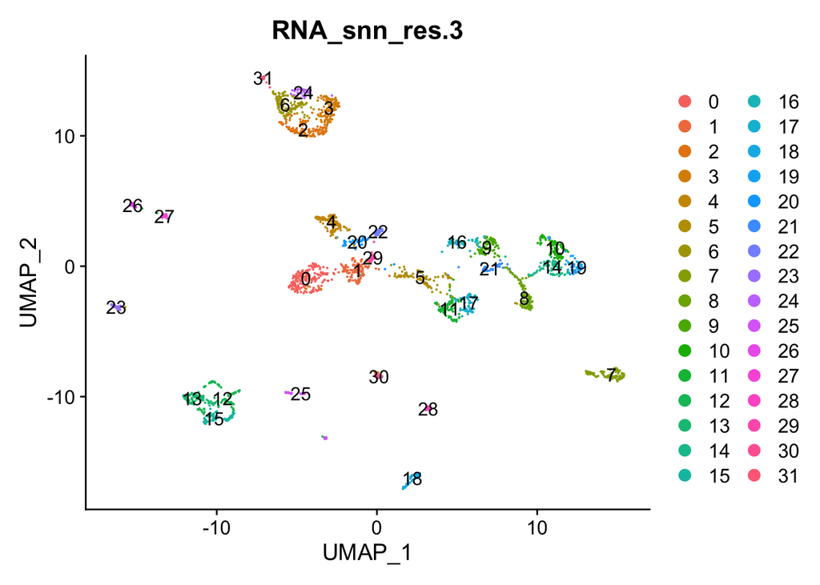

```r
DimPlot(ple5, group.by="RNA_snn_res.3", label=TRUE, pt.size = 0.05)
```

The higher the resolution, the more the clusters. For a resolution of 3, the 2334 cells are divided between 32 different clusters.

The expression of selected genes can be visualized in the UMAP graph.

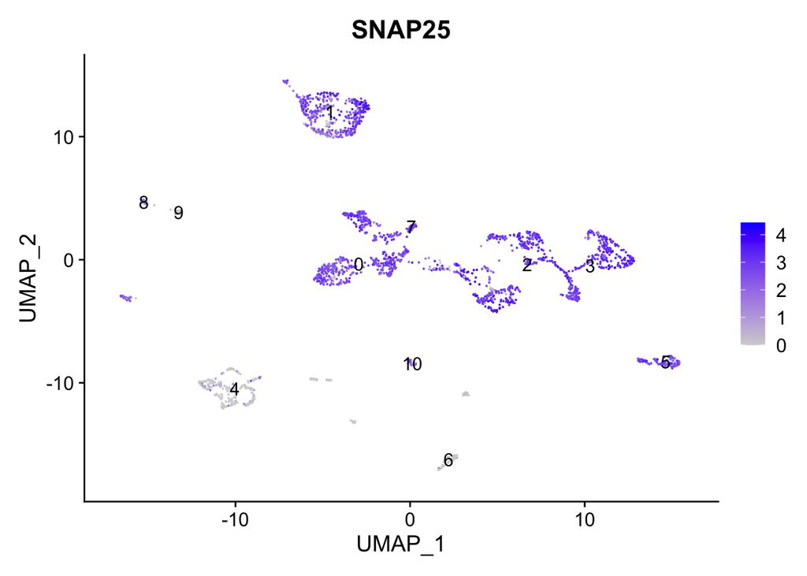

```r
ple5 <- SetIdent(ple5, value="RNA_snn_res.0.1")
FeaturePlot(object=ple5, features="SNAP25", label=TRUE, pt.size = 0.05)
```

```r
genes <- data.frame( "genes" = rownames(ple5))
```

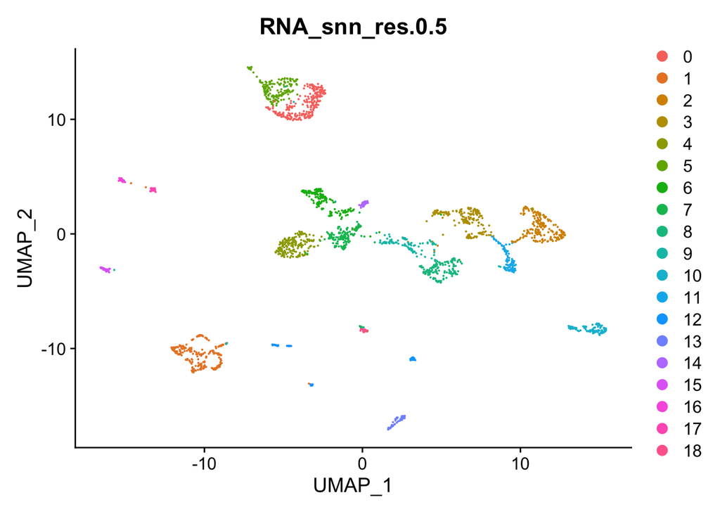

```r
DimPlot(ple5, group.by="RNA_snn_res.0.5", pt.size = 0.05)
```

We’ll use the clustering resolution 0.5 for the annotation.

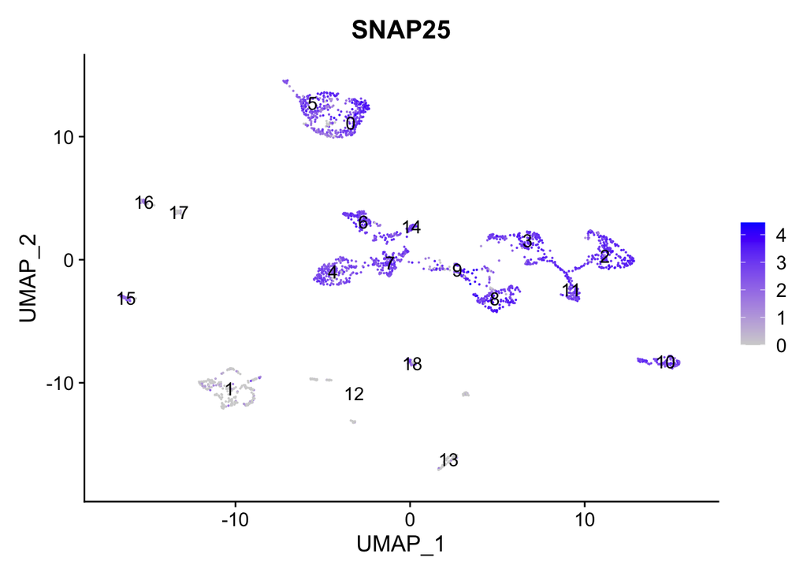

```r
ple5 <- SetIdent(ple5, value="RNA_snn_res.0.5")
FeaturePlot(ple5, features="SNAP25", label=TRUE, pt.size = 0.05)
```

Clusters are mostly homogeneous at 0.5 resolution for SNAP25 expression.

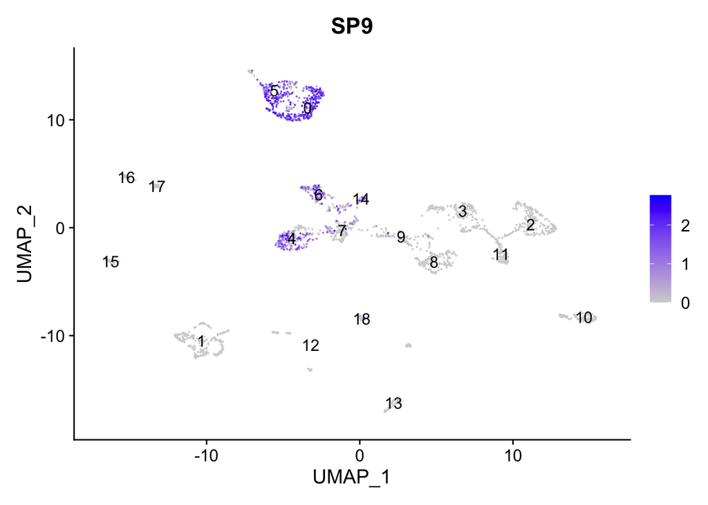

```r
FeaturePlot(ple5, features="SP9", label=TRUE, pt.size = 0.05)
```

Most clusters lack SP9 expression. Some clusters expressing SP9 are not homogeneous at 0.5 resolution.

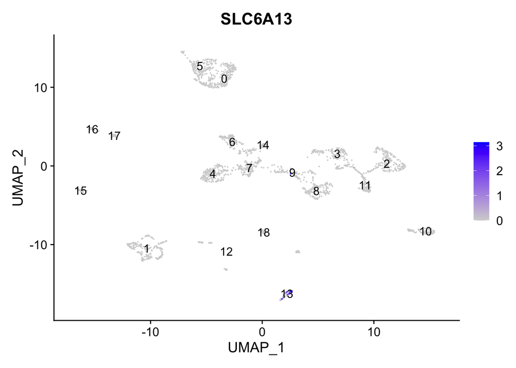

```r
FeaturePlot(ple5, features="SLC6A13", label=TRUE, pt.size = 0.05)
```

SLC6A13 appears to be cluster 13-specific.

It is also possible to plot the expression of two genes in the same graph and blend the colors to visualize the relative levels to each other.

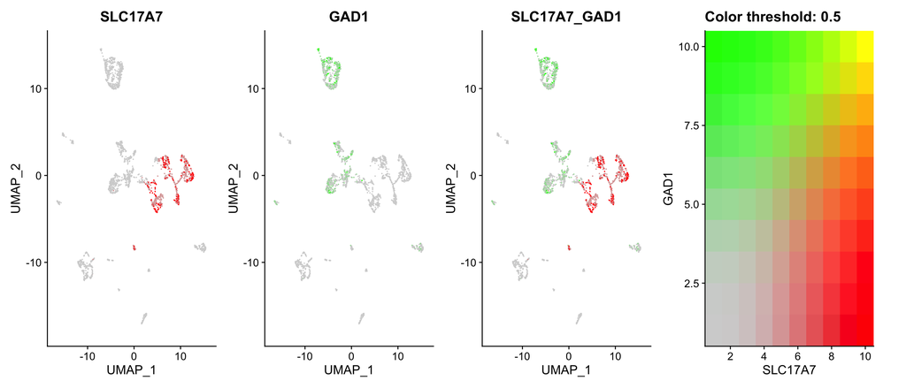

```r
FeaturePlot(ple5, features=c("SLC17A7", "GAD1"), blend=TRUE, pt.size = 0.05)
```

SLC17A7 and GAD1 appear to be mutually exclusive. This is expected, as SLC17A7 is a marker gene for excitatory neurons and GAD1 a marker gene for inhibitory neurons.

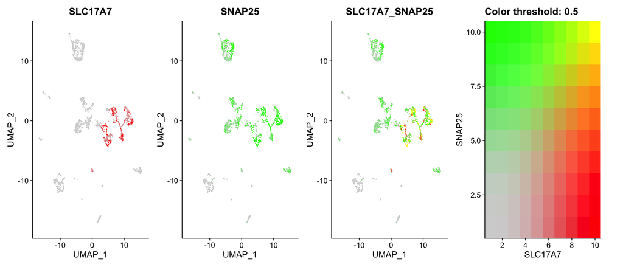

```r
FeaturePlot(ple5, features=c("SLC17A7", "SNAP25"), blend=TRUE, pt.size = 0.05)
```

SLC17A7 exhibits a tendency to co-express with SNAP25. However, the reverse pattern is not observed to the same extent, as SNAP25 is expressed in a significant number of cells and clusters even in the absence of SLC17A7.

```r
ple5 <- SetIdent(ple5, value="RNA_snn_res.0.5")
```

# Finding cluster specific genes

Find the marker genes, positive and negative, for each one of the 19 clusters against all cells. Test only genes who are expressed in at least 25% of the cells in at least one of the clusters.

```r
if (file.exists("markers_res_0.5v2.rds")) {
  ple5.markers <- readRDS("markers_res_0.5v2.rds")
} else {
  ple5.markers <- FindAllMarkers(ple5, min.pct=0.25)
}
```

## Save the markers to a file

### As RDS

```r
saveRDS(ple5.markers, "markers_res_0.5v2.rds")
```

### As TSV

```r
write.table(ple5.markers, "markers_res_0.5v2.tsv",
            quote = F, sep = "\t", row.names = T, col.names = T)
```

## Exploring gene expression of marker genes

Cluster 0 marker genes.

```r
cluster0.markers <- ple5.markers %>%
  dplyr::filter(cluster == 0) %>%
  dplyr::arrange(p_val_adj)
```

Top 5 deferentially expressed genes of cluster 0 compared to all other cells, based on the adjusted p-value.

```r
cluster0.markers_top5 <- cluster0.markers$gene[1:5]
cluster0.markers_top5
```

```
## [1] "SHISA8"  "TSHZ1"   "LAMP5"   "SLC35D3" "ZADH2"
```

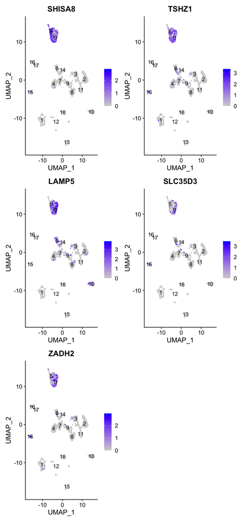

```r
FeaturePlot(ple5, features=cluster0.markers_top5, label=TRUE)
```

Another way to visualize single cell expression distributions in each cluster is the violin plot.

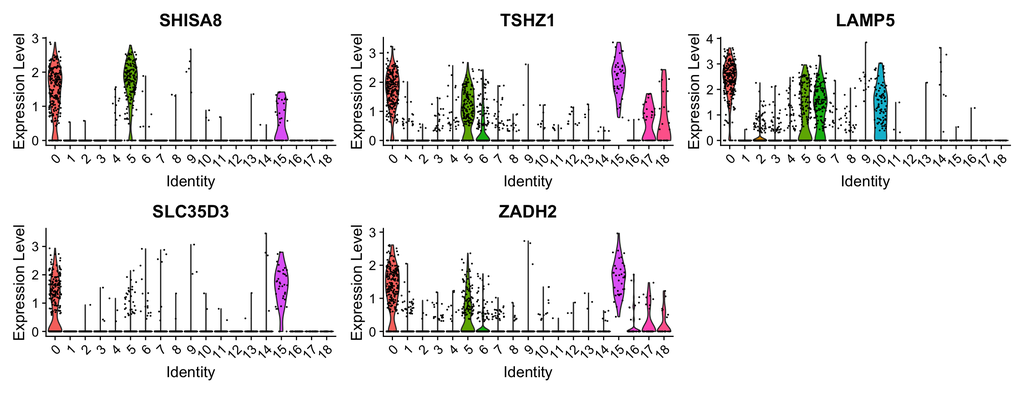

```r
VlnPlot(ple5, features=cluster0.markers_top5)
```

Some of the top markers for cluster 0 are also expressed in other clusters. The overlap is different for different markers and combined they define cluster 0 well. For example, SHISA8 performs very well in distinguishing clusters 0, 5, and to some degree cluster 15, from all the others. SLC35D3 is expressed much more strongly in cluster 0 and 15 than cluster 5. At the same time clusters 0 and 15 can be differentiated based on LAMP5 expression levels.

If necessary, it is also possible to find differentially expressed genes between specific clusters (e.g. cluster 0 and 5) in order to provide a sufficient analysis of the differences between them.

```r
ple5.cluster1.4.markers <- FindMarkers(ple5, ident.1 = 0, ident.2 = 5, min.pct = 0.25)
```

```r
cluster1.4.markers <- ple5.cluster1.4.markers %>%
  dplyr::arrange(p_val_adj)
```

```r
cluster1.4.markers[1:5,]
```

```
##                p_val avg_log2FC pct.1 pct.2    p_val_adj
## SALL3   6.274240e-43  -1.682940 0.104 0.740 8.221137e-39
## SLC6A11 1.916764e-40  -1.551237 0.400 0.935 2.511536e-36
## LAMP5   9.382702e-32   1.446326 0.960 0.639 1.229415e-27
## KCNG1   1.272119e-31  -1.636169 0.224 0.763 1.666857e-27
## SLC6A1  1.845796e-31  -1.142245 0.820 0.994 2.418547e-27
```

Positive values of log fold-change indicate that the feature is more highly expressed in the first group. SALL3 for example with a value of -1.7 is expected to be expressed higher on cluster 5. pct.1 : The percentage of cells where the feature is detected in the first group pct.2 : The percentage of cells where the feature is detected in the second group

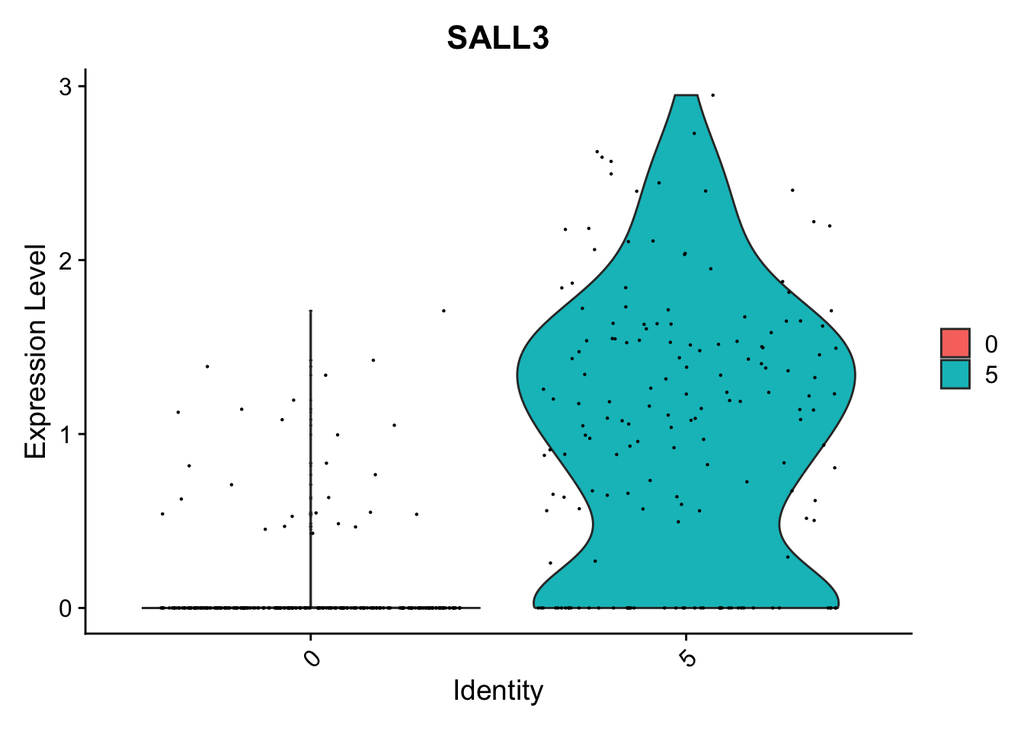

```r
VlnPlot(ple5, features="SALL3", idents=c(0,5))
```

SALL3 does not belong to the top 5 differentially expressed genes in general for cluster 0, but it can best describe the difference specifically between clusters 0 and 5.

```r
saveRDS(ple5, "srt_03_ple5v2.rds")
```